# demo_iris slides

## 使用 Iris 資料集來示範 Lime 套件

當建構出一個預測模型的時候，最常被問到的問題就是：為什麼模型會預測成這個結果？由於為了追求準確的預測，模型的架構也越來越複雜，導致很難解釋其中的奧妙。像我個人最喜歡的解釋就是：

> 啊，這個很複雜啦，很難跟你解釋。😜

如果是跟自己人報告，通常大家也都會有點相同的研究背景，可能還可以接受這個狀況。問題是如果聽報告的人是**尊敬 DER 客戶**，這樣講可就不太妙！

還好，現在有這個 [Lime](https://github.com/marcotcr/lime) 套件，多多少少幫我們解決了這個問題。有了 Lime，我們可以在建構完模型後，挑出幾個 Sample，並讓 Lime 製作圖表跟說明，讓我們解釋每個 Sample 為何會被預測為這個結果。

以下這個主題為 "Why should I trust you?" 的影片，就是在介紹 Lime 的箇中奧妙。

[figure not shown]

## 示範開始

### 使用 Iris 數據集

*Iris （鳶尾花）資料集*是個時常被用來作為數據分析或是統計分析時示範的資料集，大致上就是可以依據一朵鳶尾花中花萼、花瓣的寬度、長度，來預測鳶尾花的品種分別為*山鳶尾 (Setosa)*、*變色鳶尾 (Versicolor)* 和*維吉尼亞鳶尾 (Virginica)*。

資料集全名為[*安德森鳶尾花卉數據集 (Anderson's Iris data set)*](https://zh.wikipedia.org/wiki/安德森鸢尾花卉数据集)，可以前往維基百科的[相關條目](https://zh.wikipedia.org/wiki/安德森鸢尾花卉数据集)了解詳情。

> 看看他們的長相或許可以加深記憶 😊

山鳶尾 (Setosa)：

[figure not shown]

變色鳶尾 (Verisicolor)：

[figure not shown]

維吉尼亞鳶尾 (Virginica)：

[figure not shown]

*Scikit-learn* 很貼心的幫我們建立好了。透過以下的方法叫就可以使用：

```python
# 讀取範例資料集 Iris
iris = sklearn.datasets.load_iris()
```

如果還需要使用不同的資料集，請參見 Scikit-learn: Dataset loading utilities 文件。

### 訓練模型

```python
# 將數據集以 8:2 的比例，分割為訓練資料與測試資料
X_train, X_test, y_train, y_test = train_test_split(iris.data, iris.target,
                                                          train_size=0.80,
                                                          test_size=0.20,
                                                          random_state=1)
```

```python
# 使用 Random Forest Classifier 製作分類模型
rf = sklearn.ensemble.RandomForestClassifier(n_estimators=50, random_state=1)
rf.fit(X_train, y_train)
```

```
RandomForestClassifier(bootstrap=True, class_weight=None, criterion='gini',
            max_depth=None, max_features='auto', max_leaf_nodes=None,
            min_impurity_decrease=0.0, min_impurity_split=None,
            min_samples_leaf=1, min_samples_split=2,
            min_weight_fraction_leaf=0.0, n_estimators=50, n_jobs=1,
            oob_score=False, random_state=1, verbose=0, warm_start=False)
```

```python
# 計算模型的準確度分數
y_pred = rf.predict(X_test)
score = sklearn.metrics.accuracy_score(y_test, y_pred)
```

### 使用 Lime 解釋模型

我們要找一筆資料，並透過 Lime 來觀察她「為什麼會被分到某一類？」。

在這之前，我們先觀察一下原始資料的長相：

```python
# 指定一筆資料來觀察。這裡使用 index 為 0 的 Sample
i = 0
```

```python
# 檢視原始資料
X_test[i]
```

```
array([ 5.8,  4. ,  1.2,  0.2])
```

指定要觀察的 Sample 的 Index = 0。其中：

| 特徵 | 實際數值 |
| --- | --- |
| sepal length (cm) | 5.7999999999999998 |
| sepal width (cm) | 4.0 |
| petal length (cm) | 1.2 |
| petal width (cm) | 0.20000000000000001 |

接著將這筆資料放入模型中預測：

```python
# 使用 predict_proba() 來預測結果
pred = rf.predict_proba([X_test[i]])[0]
pred
```

```
array([ 0.94,  0.06,  0.  ])
```

這個 Sample 會被預測為各個 Label 的機率：

| 被預測的 Label | 機率 |
| --- | --- |
| setosa | 0.93999999999999995 |
| versicolor | 0.059999999999999998 |
| virginica | 0.0 |

接著總算可以來操作 Lime 了！

剛才這些手動的過程，都可以透過 Lime 幫我們製作圖表，甚至還有更詳細的資訊噢 😄。

首先建立一個 Explainer 類別。

依據不同的資料類型，有不同的參數可以設定，設定的方式可以參考 Lime GitHub Repo 裡的 [Tutorials and API](https://github.com/marcotcr/lime#tutorials-and-api) 章節，依照範例裡使用的資料集的型態，來挑選適當的參數。

```python
explainer = lime.lime_tabular.LimeTabularExplainer(X_train,
                                                   feature_names=iris.feature_names,
                                                   class_names=iris.target_names,
                                                   discretize_continuous=True)
```

再來，建立一個 Explainer 的實體物件，並觀察她的預測情況。

```python
exp = explainer.explain_instance(X_test[i], rf.predict_proba,
                                 num_features=2, top_labels=1)
```

其中有幾個比較重要的參數，分別解釋一下：

- `num_features`: 等一下的報告中，要顯示原始資料的 Feature 數。會依照各個 Feature 在預測時的重要性，挑選前幾個出來展示
- `top_levels`: 等一下的報告中，要顯示的預測 Label 及各個 Feature 影響力的直方圖的數量。會依照被預測為各個 Label 的機率大小，顯示前 n 個 Label 及 Feature 影響預測為這個 Label 的結果

圖表是用 HTML 產生的，所以可以直接在 Notebook 裡面顯示，使用的 Method 為 `show_in_notebook`：

`exp.show_in_notebook(show_table=True, show_all=False)`

也可以存為 HTML 網頁檔，使用的 Method 為 `save_to_file`：

`exp.save_to_file("exp.html")`

有時候我們發現因為文字太長的關係，會導致某些文字無法顯示清楚。

這時可以搭配一些 Method 來檢視這些數值：

```python
# 觀察被預測為各個 Label 的機率
exp.predict_proba
```

```
array([ 0.94,  0.06,  0.  ])
```

```python
# 這是一個好用的技巧，讓我們在觀察某個 Label 的相關資料時，不用記下各個 Lable 的 Index
label_index = lambda x: list(iris.target_names).index(x)
```

```python
# 觀察各個 Feature 影響這個 Sample 被預測為 setosa 的機率
exp.as_list(label_index("setosa"))
```

```
[('petal length (cm) <= 1.60', 0.44233893589428919),
 ('petal width (cm) <= 0.30', 0.393086337781553)]
```

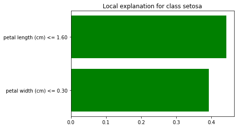

```python
# 用更大的圖表來檢視
exp.as_pyplot_figure(label_index("setosa"))
```

當然，也可以在一開始製作 Explainer 物件實體時，就顯示所有的資料：

```python
exp = explainer.explain_instance(X_test[i], rf.predict_proba,
                                 num_features=len(iris.feature_names),
                                 top_labels=len(iris.target_names))
```

這樣就可以檢視被預測為其他類別的條件囉～

```python
# 觀察各個 Feature 影響這個 Sample 被預測為 versicolor 的機率
exp.as_list(label_index("versicolor"))
```

```
[('petal length (cm) <= 1.60', -0.15145186949152811),
 ('petal width (cm) <= 0.30', -0.12919429157701426),
 ('5.10 < sepal length (cm) <= 5.80', 0.01169030352008031),
 ('sepal width (cm) > 3.30', -0.006631335816182248)]
```

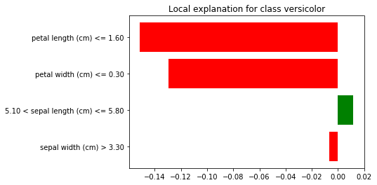

```python
# 用更大的圖表來檢視
exp.as_pyplot_figure(label_index("versicolor"))
```

✨🍰 The End. 🍰✨